```python
import numpy as np
import matplotlib.pyplot as plt
from scipy.io.wavfile import read
from scipy.signal import tf2zpk
from IPython.display import Audio
```

```python
# reading the wavfile
samp_rate, waveform = read("uh.wav")
assert samp_rate == 8000
```

# 1 Pre-emphasis

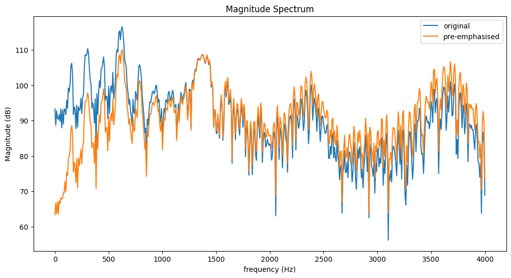

```python
# funciton to apply pre-emphasis
def preemphasis(x, coef):
    y = np.zeros_like(x)
    y[0] = x[0]
    y[1:] = x[1:] - coef * x[:-1]
    return y


# coefficient to be used for pre-emphasis
alpha = 0.95
# getting the pre-emphassied waveform
preemphasised_waveform = preemphasis(waveform, alpha)

# function to plot the magnitude response
def plot_mag(y, samp_rate, size=1024, label=""):
    mag = np.abs(np.fft.rfft(y, size))
    plt.plot(np.fft.rfftfreq(size, 1/samp_rate), 20*np.log10(mag), label=label)
    return mag


# plotting the magnitude spectra of the original an the pre-emphasised signal
plt.figure(figsize=(12, 6))
plot_mag(waveform, samp_rate, label="original")
plot_mag(preemphasised_waveform, samp_rate, label="pre-emphasised")
plt.title("Magnitude Spectrum")
plt.xlabel("frequency (Hz)")
plt.ylabel("Magnitude (dB)")
plt.legend()
plt.show()
```

We can observe that the pre-emphasised signal (orange) has higher energy in the high-frequency components when compared with the original signal (blue). But, correspondingly the original signal has higher energy in the lower frequency components.

# 2 Narrowband spectrum

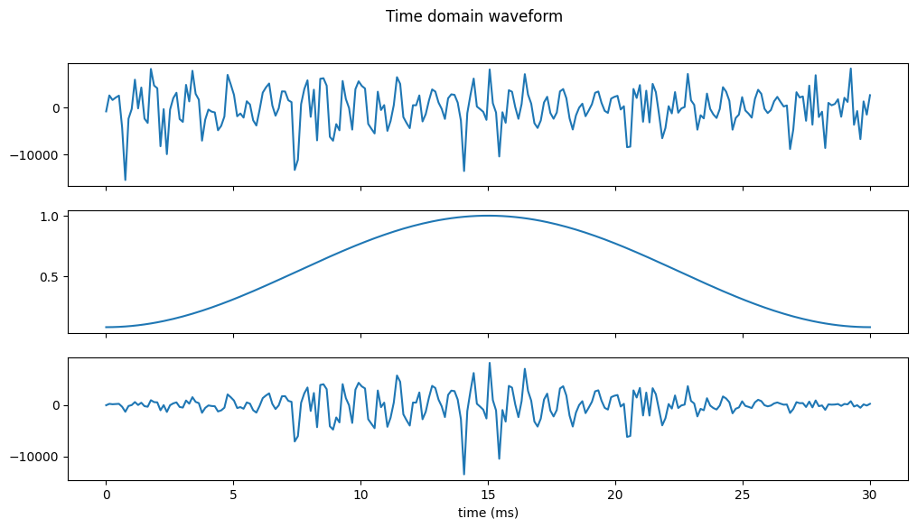

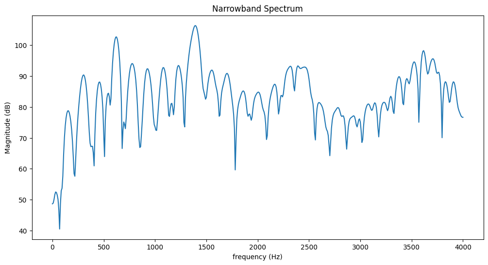

```python
# window duration as given in the assignment
window_duration = 30e-3
# the window length in terms of number of samples
window_length = int(samp_rate * window_duration)
# starting index of the segment in the middle of the pre-emphasised waveform such that the window can be applied
i = (preemphasised_waveform.shape[0] - window_length)//2
# the segment from the middle of the pre-emphasised waveform
segment = preemphasised_waveform[i:i+window_length]
# the hamming window
window = np.hamming(window_length)
# windowed segment
windowed_segment = window * segment

# comparing the time domain segment, window, and the windowed segment
time = np.linspace(0, window_duration, window_length) * 1e3
_, ax = plt.subplots(nrows=3, sharex=True, figsize=(12, 6))
plt.suptitle("Time domain waveform")
ax[0].plot(time, segment)
ax[1].plot(time, window)
ax[2].plot(time, windowed_segment)
plt.xlabel("time (ms)")
plt.show()

# computing and plotting the magnitude spectrum of the windowed segment
plt.figure(figsize=(12, 6))
# magnitude is returned from the plotting function
mag = plot_mag(windowed_segment, samp_rate=samp_rate)
plt.title("Narrowband Spectrum")
plt.xlabel("frequency (Hz)")
plt.ylabel("Magnitude (dB)")
plt.show()
```

We can see that the harmonics in the spectrum are distinguishable at a glance, which is characteristic of a narrowband spectrum (high harmonic resolution and low formant resolution)

# 3 Autocorrelation and LP coefficients

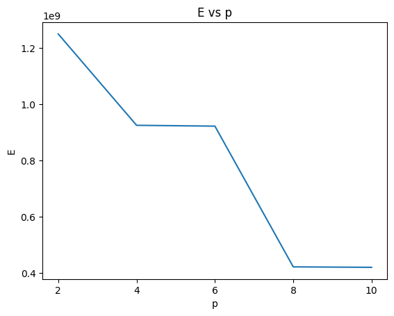

```python
# function to calculate the autocorrelation for a specific lag
def acf(x, lag):
    return np.sum( x[lag:] * x[:x.shape[0] - lag] ) if lag < x.shape[0] else 0

# function to calculate the autocorrelation coefficients for lag 0 to p
def acf_coeffs(x, p):
    c = np.zeros(p+1)
    for i in range(p+1):
        c[i] = acf(x, i)
    return c

# function to perform the Levinson-Durbon recurion for computing lp coeffs
def levinson_durbin_recursion(r):
    p = r.shape[0] - 1
    E = np.zeros(p+1)
    k = np.zeros(p+1)
    a = np.zeros((p+1, p+1))

    E[0] = r[0]

    # i = 1
    k[1] = r[1] / E[0]
    a[1, 1] = k[1]
    E[1] = (1 - k[1]**2) * E[0]

    # i = 2 to p
    for i in range(2, p+1):
        k[i] = (r[i] - np.dot(a[i-1, 1:i], r[i-1:0:-1])) / E[i-1]
        a[i, i] = k[i]

        for j in range(1, i):
            a[i, j] = a[i-1, j] - k[i] * a[i-1, i-j]

        E[i] = (1 - k[i]**2) * E[i-1]

    return E, k, a


# for LPC calculation upto p = 10
p = 10
# autocorrelation coefficients with lag from from 0 to 10 which is taken care of inside the function
r = acf_coeffs(windowed_segment, p)
assert r.shape[0] == p+1

# getting the lp coeffs
E, k, a = levinson_durbin_recursion(r)

# plotting E vs p
plt.plot(range(2, p+1, 2), E[2::2])
plt.title("E vs p")
plt.xlabel("p")
plt.ylabel("E")
plt.xticks(range(2, p+1, 2))
plt.show()
```

The error decreases as we increase the number of poles in our all pole estimation of the spectrum.

# 4 Pole-zero plots

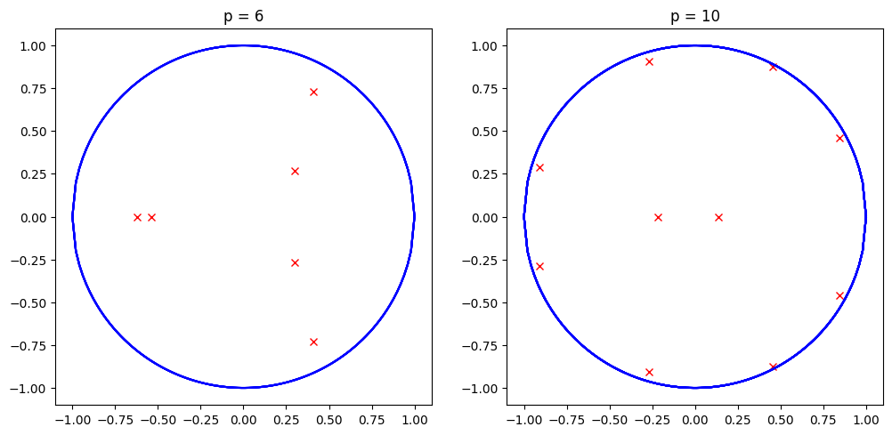

```python
# for plotting the unit circle
x = np.linspace(-1, 1, 100)
y = np.sqrt(1-x**2)
# plotting the poles for p = 6, and 10
_, ax = plt.subplots(ncols=2, figsize=(12, 5.5))
for i, p_ in enumerate((6, 10)):
    b = np.ones(1)
    poles = tf2zpk(b, np.concatenate((b, -a[p_][1:p_+1])))[1]
    for pole in poles:
        ax[i].plot(pole.real, pole.imag, 'rx')
        ax[i].plot(x, y, 'b')
        ax[i].plot(x, -y, 'b')
        ax[i].set_title(f"p = {p_}")
plt.show()
```

Observations:

1. all poles lie inside the unit circle.
2. The poles for p = 10 are placed closer to the unit circle when compared to p = 6.
3. This will lead to the magnitude spectrum being more peaky for higher p.

# 5 LPC spectrum

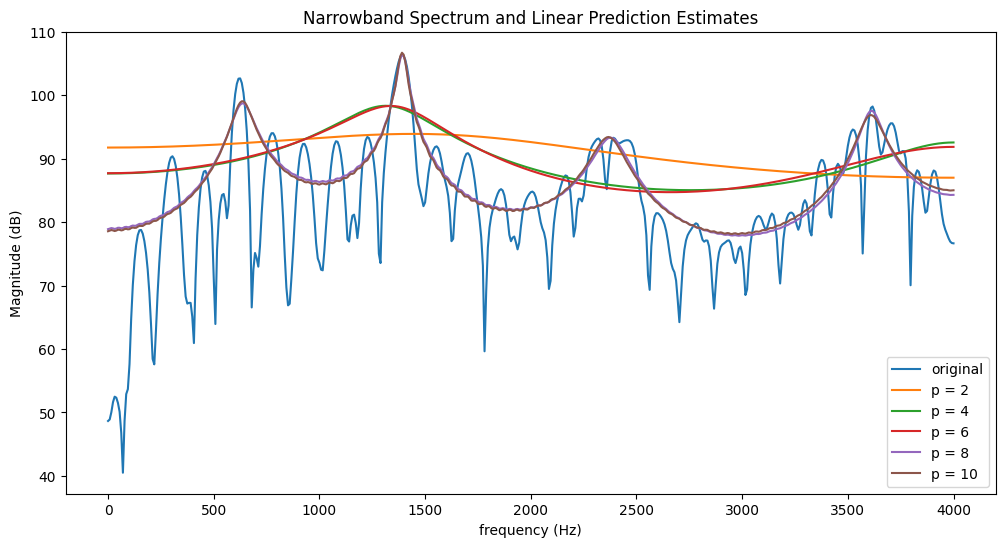

```python
# function to generate the impulse response of the all pole filter
# which is nothing but the estimate of the signal using linear prediction
def lp(E, a, len):
    y = np.zeros(a.shape[0]+len-1)
    y[a.shape[0]-1] = np.sqrt(E)
    for i in range(a.shape[0], a.shape[0]+len-1):
        y[i] = np.dot(y[i-a.shape[0]:i], a[::-1])
    return y[a.shape[0]-1:]


# for storing the computed magnitude and estimated waveforms
magnitudes, estimated_waveforms = {}, {}
plt.figure(figsize=(12, 6))
# plotting the original narrowband spectrogram for comparison
plot_mag(windowed_segment, samp_rate, label="original")
# plotting the estimates for different number of poles in the same plot
for p_ in range(2, p+1, 2):
    estimated_waveforms[p_] = lp(E[p_], a[p_][1:p_+1], window_length)
    magnitudes[p_] = plot_mag(estimated_waveforms[p_], samp_rate, label="p = " + str(p_))
plt.title("Narrowband Spectrum and Linear Prediction Estimates")
plt.xlabel("frequency (Hz)")
plt.ylabel("Magnitude (dB)")
plt.legend()
plt.show()
```

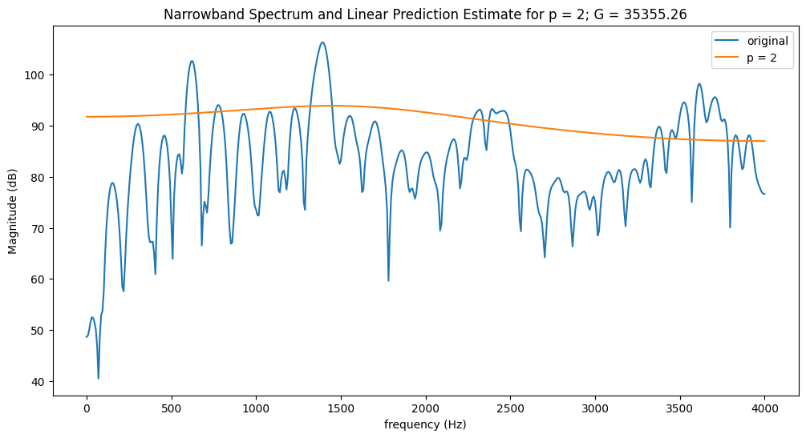

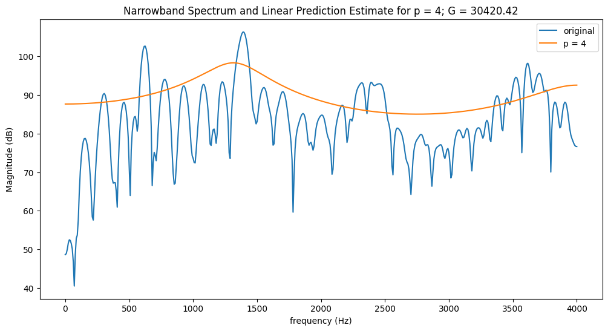

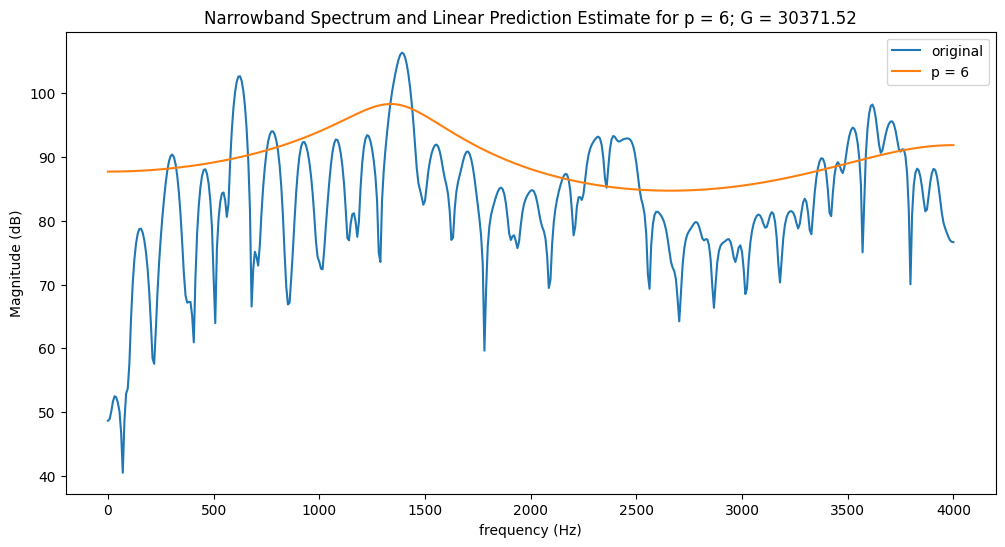

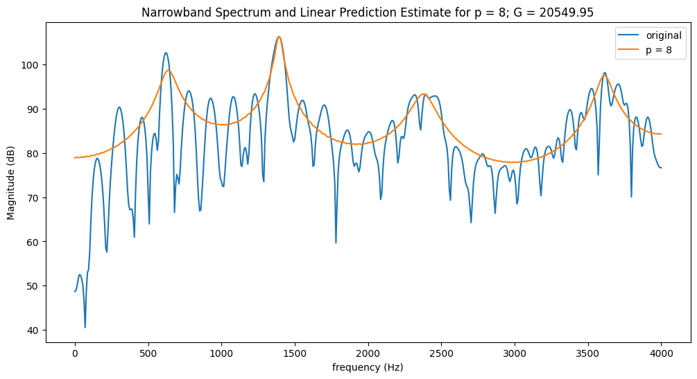

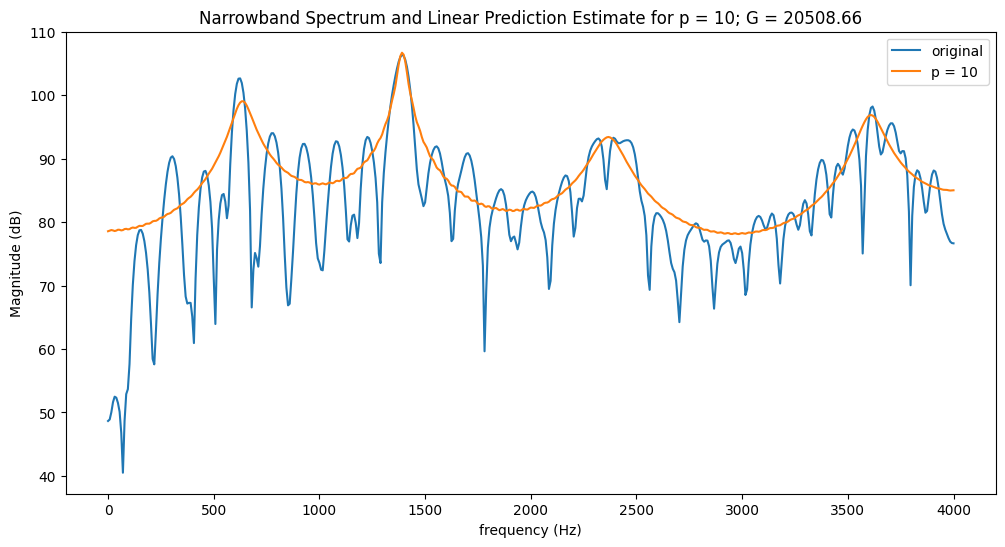

```python
# plotting the different approximates seperately
for p_ in range(2, p+1, 2):
    plt.figure(figsize=(12, 6))
    plot_mag(windowed_segment, samp_rate, label="original")
    plot_mag(estimated_waveforms[p_], samp_rate, label="p = " + str(p_))
    plt.title("Narrowband Spectrum and Linear Prediction Estimate for p = " + str(p_) + "; G = " + str(np.round(np.sqrt(E[p_]), 2)))
    plt.xlabel("frequency (Hz)")
    plt.ylabel("Magnitude (dB)")
    plt.legend()
    plt.show()
```

Comments:

p = 2 : The spectrum is smooth and varies very slowly. It is not a good approximation by any metric.

p = 4 : The spectrum is able to identify one of the formants and then slowly follows the general trend of the spectrum.

p = 6 : This spectrum closely follows the p = 4 spectrum, with very small variations.

p = 8 : Here, we can see that all the four formants have been identified. Also, the error in approximating the peaks is very less, and the error in approximating the valleys is high.

p = 10 : This spectrum very closely matches the p = 8 spectrum, but the small amplitude oscillations are visible in the spectrum.

As the number of poles in the approximation increases, the hidden envelope estimate gets better, and we have smaller overall error and better formant approximations.

# 6 Inverse Filtering

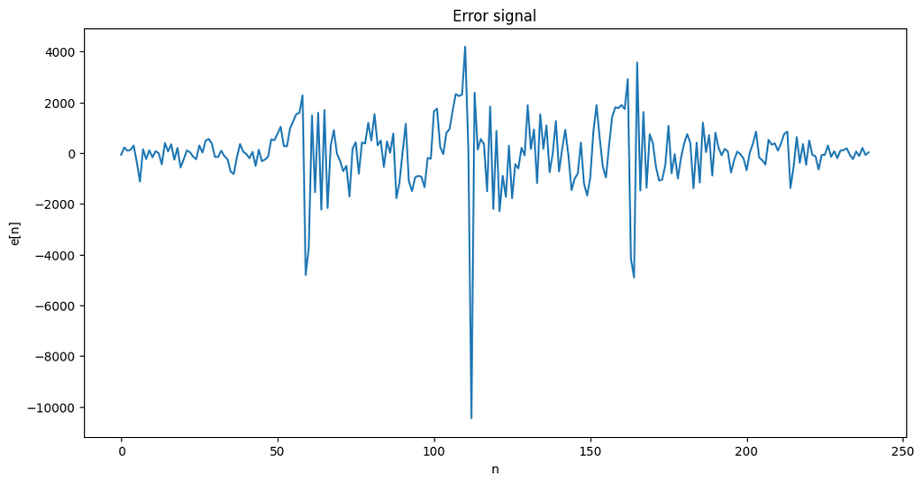

```
Period: 52.5 samples
Pitch: 152.38095238095238 Hz
```

```python
# function to do inverse filtering on the signal
# the inverse filter is A(z) => E(z) = S(z)A(z)
def inverse_filter(signal, a):
    signal = np.concatenate((np.zeros(a.shape[0]), signal))
    error = signal[a.shape[0]:]
    for i in range(a.shape[0]):
        error = error - a[i] * signal[a.shape[0]-i-1:-i-1]
    return error


# inverse filtering the original waveform segment to obtain the residual error signal
# the value of p is already 10
residual_error_signal = inverse_filter(windowed_segment, a[p][1:p+1])
# plotting the residual error signal waveform
plt.figure(figsize=(12, 6))
plt.plot(residual_error_signal)
plt.title("Error signal")
plt.xlabel("n")
plt.ylabel("e[n]")
plt.show()

# measureing the pitch
# since we can see three peaks in the waveform, we calculate their locations
peak_indices = np.sort(np.argpartition(residual_error_signal, 3)[:3])
# the period (in samples) can be estimated by the difference in their positions
period = (peak_indices[2]-peak_indices[1] + peak_indices[1]-peak_indices[0]) / 2
print("Period:", period, "samples")
# then the pitch will be sampling rate divided by the period (in samples)
pitch = samp_rate / period
print("Pitch:", pitch, "Hz")
```

```python
# computing the acf for all positive values of lag possible
lag = window_length
acf_residual_error_signal = acf_coeffs(residual_error_signal, lag)
# the period (in samples) is the first major peak of the acf after index 0
period = np.argmax(acf_residual_error_signal[1:])
print("Period:", period, "samples")
pitch = samp_rate / period
print("Pitch:", pitch, "Hz")
```

```
Period: 51 samples
Pitch: 156.86274509803923 Hz
```

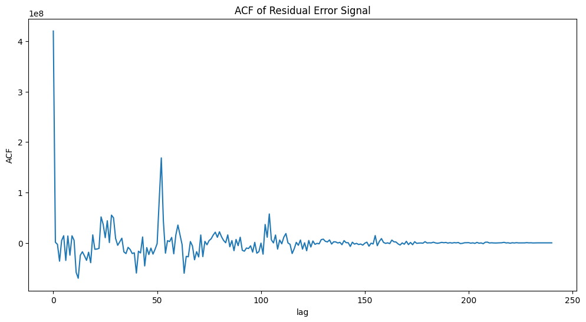

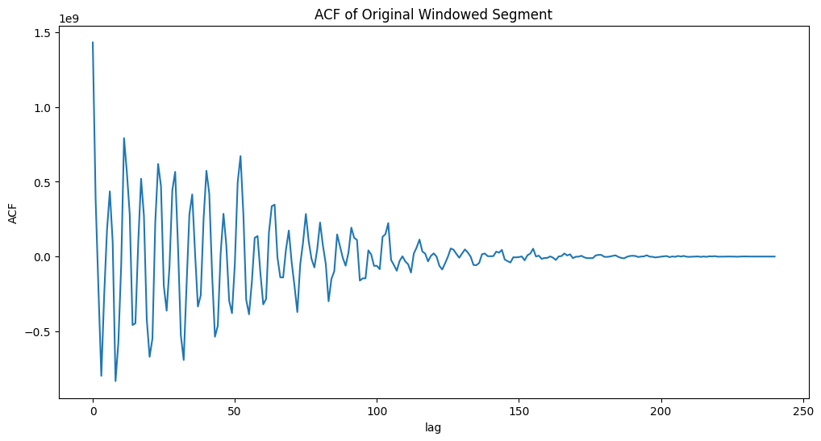

```python
# comparing the acf plots

plt.figure(figsize=(12, 6))
plt.plot(acf_residual_error_signal)
plt.title("ACF of Residual Error Signal")
plt.xlabel("lag")
plt.ylabel("ACF")
plt.show()

acf_windowed_segment = acf_coeffs(windowed_segment, lag)
plt.figure(figsize=(12, 6))
plt.plot(acf_windowed_segment)
plt.title("ACF of Original Windowed Segment")
plt.xlabel("lag")
plt.ylabel("ACF")
plt.show()
```

Comments:

The acf plot of the residual signal is more distinguishable peaks, when compared to the acf of the original windowed segment, which as several high amplitude peaks near lag 0.

The value of lag after which both the acf plots decay to 0 seems to be similar and around 180.

The peaks in the acf of the residual signal that are present at the values of lag which are a multiple of period, appear to be tapered, which is beacuse of the Hamming window that we had chosen.

# 7 LP Re-Synthesis

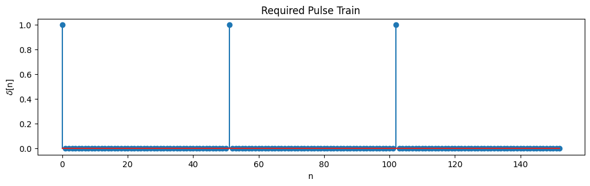

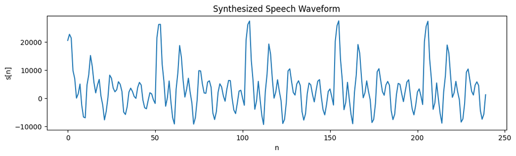

[interactive chart not shown]

```python
# function to get the output of a periodic source excitation
def filter(E, a, len, source):
    y = np.zeros(a.shape[0]+len-1)
    y[a.shape[0]-1] = np.sqrt(E) * source[0]
    for i in range(a.shape[0], a.shape[0]+len-1):
        y[i] = np.dot(y[i-a.shape[0]:i], a[::-1]) + np.sqrt(E) * source[(i-a.shape[0]+1) % source.shape[0]]
    return y[a.shape[0]-1:]

# function to perform de-emphasis on the signal
def deemphasis(x, coef):
    y = np.zeros_like(x)
    y[0] = x[0]
    for i in range(1, y.shape[0]):
        y[i] = x[i] + coef * y[i-1]
    return y


# best estimated of LP Filter
ak = a[10][1:]
E_ = E[10]

# one period of the ideal impulse train with the estimate period
pulse_train = np.concatenate((np.ones(1), np.zeros(period - 1)))
plt.figure(figsize=(12, 3))
plt.stem(list(pulse_train)*3)
plt.title("Required Pulse Train")
plt.xlabel("n")
plt.ylabel(r"$\delta$[n]")
plt.show()

# duration of the synthesized speech
synth_duration = 300e-3
synth_length = int(samp_rate * synth_duration)

# synthesizeing
synth_speech = filter(E_, ak, synth_length, pulse_train)

# applying de-emphasis
synth_speech = deemphasis(synth_speech, alpha)

# plotting a few periods of and listening to the synthesized speech
plt.figure(figsize=(12, 3))
plt.plot(synth_speech[:window_length])
plt.title("Synthesized Speech Waveform")
plt.xlabel("n")
plt.ylabel("s[n]")
plt.show()
Audio(data=synth_speech, rate=samp_rate)
```

```python
# original speech segment
Audio(data=waveform, rate=samp_rate)
```

[interactive chart not shown]

Because Linear Prediction is better suited for voiced sound where the sound is characterizable by its formants, the /uh/ or /a/ utterance characteristics can be accurately captured by the LP Coefficients and we get a good synthesized sound.

The synthesized waveform is perfectly periodic and thus it does not sound natural bcause we have not introduced pith jitter, shimmer, and lip radiotion etc.

```python
# pitch variation:
# this can be carried out by changing the period when generating the pulse train
low_period = 40
high_pitch_pulse_train = np.concatenate((np.ones(1), np.zeros(low_period - 1)))
high_pitch_synth_speech = filter(E_, ak, synth_length, high_pitch_pulse_train)
high_pitch_synth_speech = deemphasis(high_pitch_synth_speech, alpha)

high_period = 80
low_pitch_pulse_train = np.concatenate((np.ones(1), np.zeros(high_period - 1)))
low_pitch_synth_speech = filter(E_, ak, synth_length, low_pitch_pulse_train)
low_pitch_synth_speech = deemphasis(low_pitch_synth_speech, alpha)
```

```python
# utterance with high pitch (200 Hz = 8000/40)
Audio(data=high_pitch_synth_speech, rate=samp_rate)
```

[interactive chart not shown]

```python
# utterance with high pitch (100 Hz = 8000/80)
Audio(data=low_pitch_synth_speech, rate=samp_rate)
```

[interactive chart not shown]

# 8 Complete LP Analysis for /s/ utterance

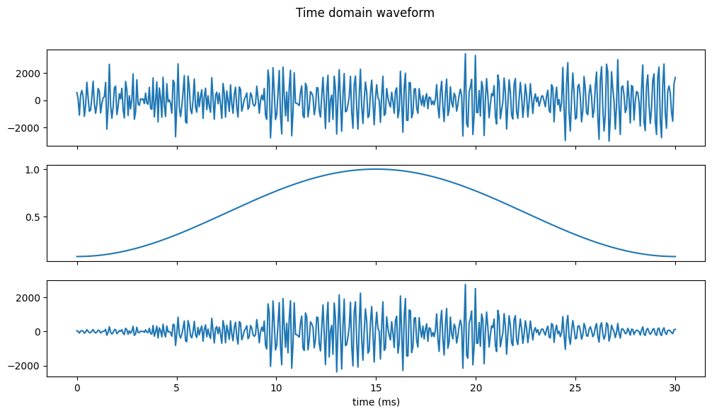

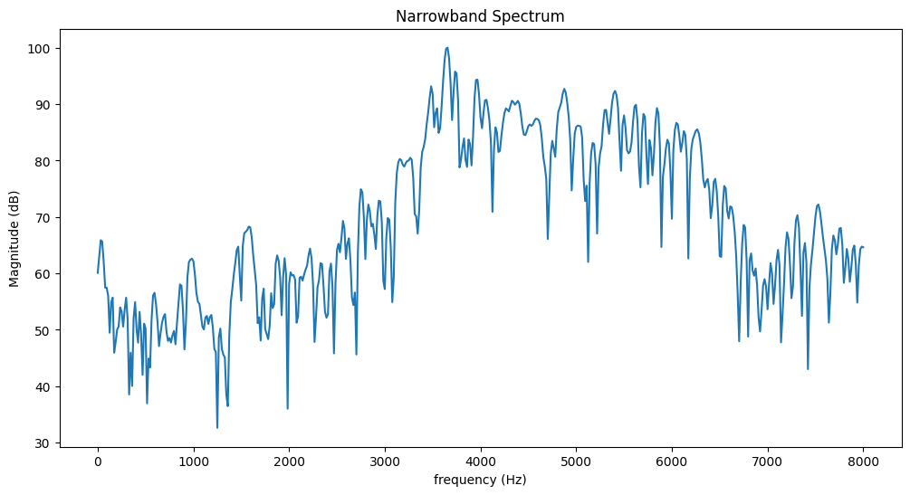

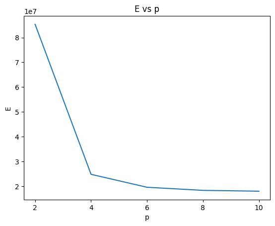

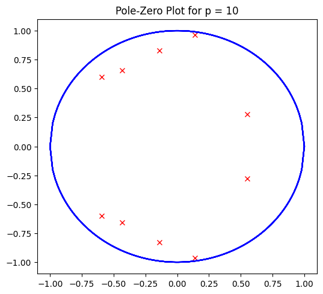

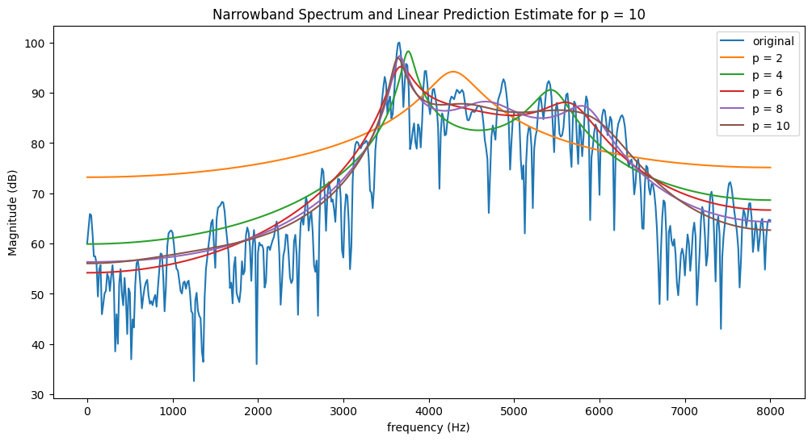

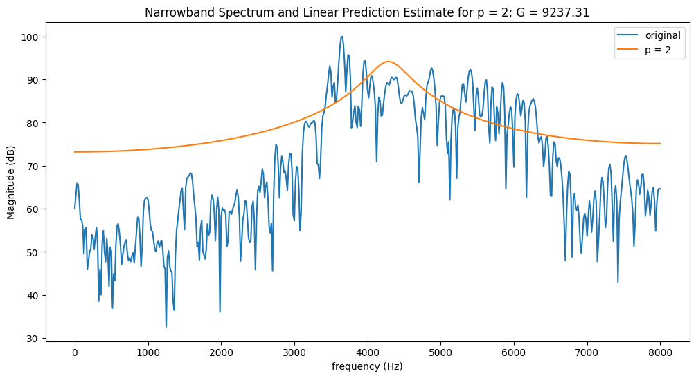

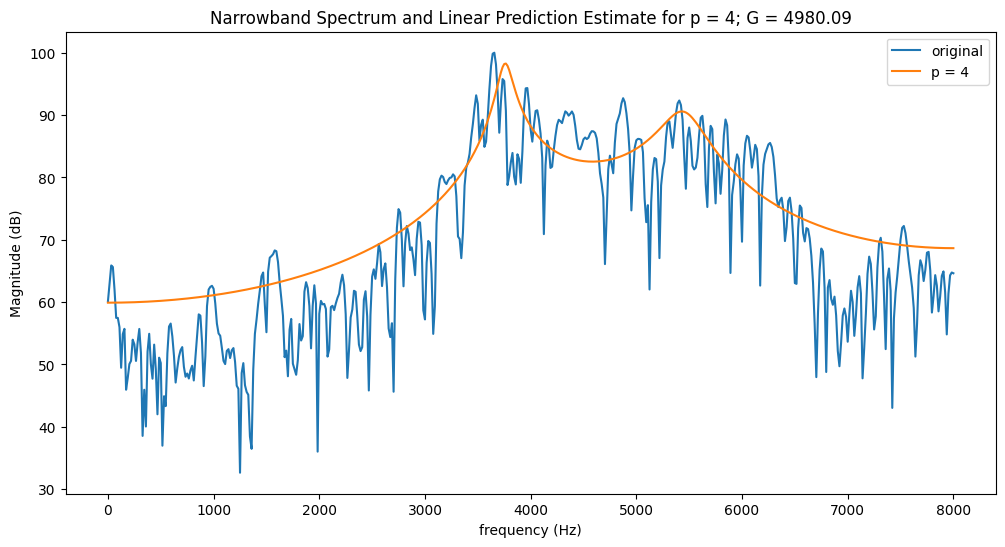

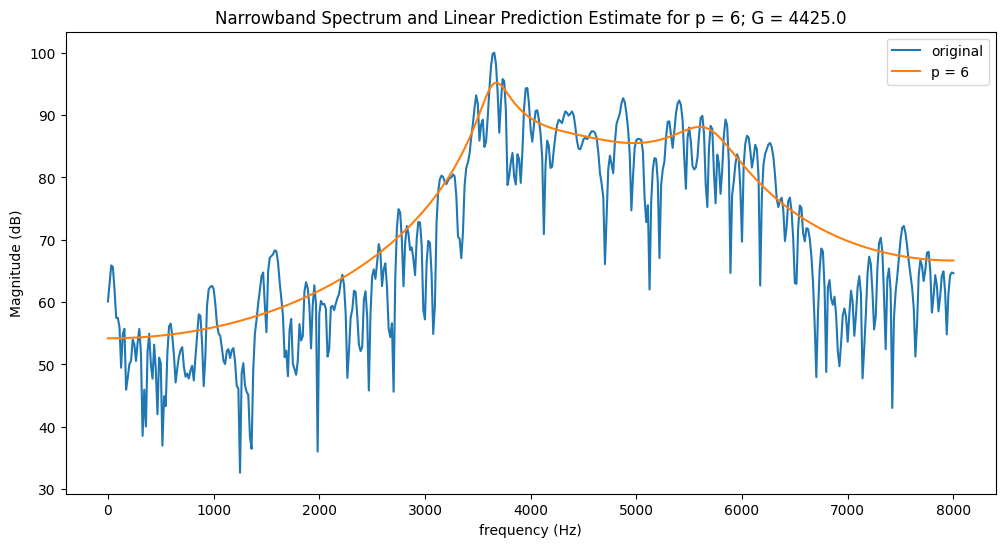

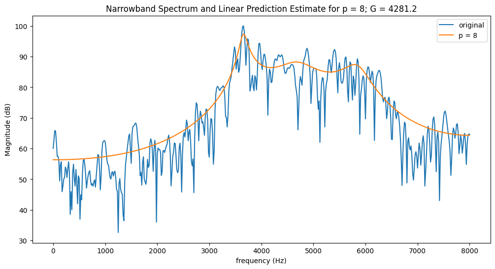

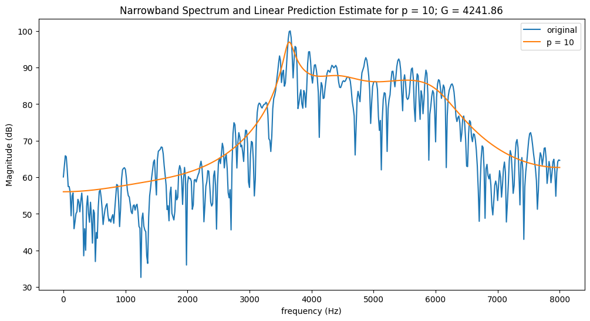

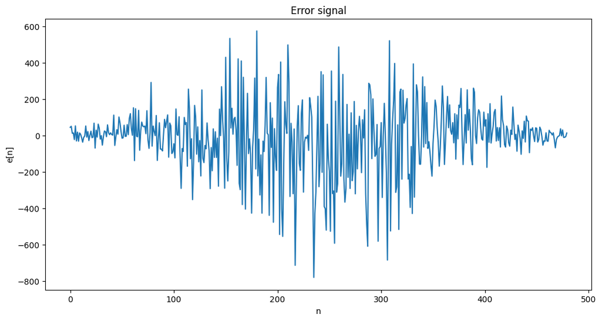

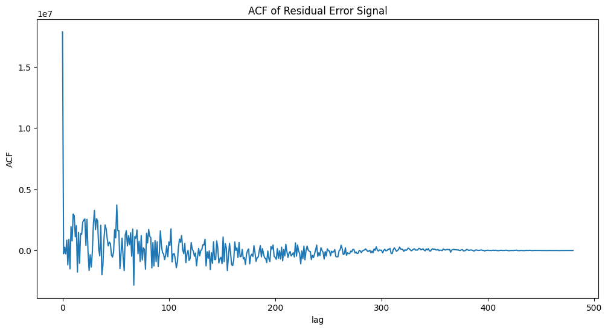

[3 more figures not shown]

```
Period: 50 samples
Pitch: 320.0 Hz
```

[interactive chart not shown]

```python
samp_rate, waveform = read("ss.wav")
assert samp_rate == 16000
alpha = 0.95
preemphasised_waveform = preemphasis(waveform, alpha)

window_duration = 30e-3
window_length = int(samp_rate * window_duration)
i = (preemphasised_waveform.shape[0] - window_length)//2
segment = preemphasised_waveform[i:i+window_length]
window = np.hamming(window_length)
windowed_segment = window * segment

time = np.linspace(0, window_duration, window_length) * 1e3
_, ax = plt.subplots(nrows=3, sharex=True, figsize=(12, 6))
plt.suptitle("Time domain waveform")
ax[0].plot(time, segment)
ax[1].plot(time, window)
ax[2].plot(time, windowed_segment)
plt.xlabel("time (ms)")
plt.show()

plt.figure(figsize=(12, 6))
mag = plot_mag(windowed_segment, samp_rate=samp_rate)
plt.title("Narrowband Spectrum")
plt.xlabel("frequency (Hz)")
plt.ylabel("Magnitude (dB)")
plt.show()

p = 10
r = acf_coeffs(windowed_segment, p)
assert r.shape[0] == p+1

E, k, a = levinson_durbin_recursion(r)

plt.plot(range(2, p+1, 2), E[2::2])
plt.title("E vs p")
plt.xlabel("p")
plt.ylabel("E")
plt.xticks(range(2, p+1, 2))
plt.show()

x = np.linspace(-1, 1, 100)
y = np.sqrt(1-x**2)
b = np.ones(1)
poles = tf2zpk(b, np.concatenate((b, -a[p][1:p+1])))[1]
plt.figure(figsize=(6, 5.5))
for pole in poles:
    plt.plot(pole.real, pole.imag, 'rx')
    plt.plot(x, y, 'b')
    plt.plot(x, -y, 'b')
plt.title("Pole-Zero Plot for p = 10")
plt.show()

magnitudes, estimated_waveforms = {}, {}
plt.figure(figsize=(12, 6))
plot_mag(windowed_segment, samp_rate, label="original")
for p_ in range(2, p+1, 2):
    estimated_waveforms[p_] = lp(E[p_], a[p_][1:p_+1], window_length)
    magnitudes[p_] = plot_mag(estimated_waveforms[p_], samp_rate, label="p = " + str(p_))
plt.title("Narrowband Spectrum and Linear Prediction Estimate for p = 10")
plt.xlabel("frequency (Hz)")
plt.ylabel("Magnitude (dB)")
plt.legend()
plt.show()

magnitude, estimated_waveform = magnitudes[10], estimated_waveforms[10]

for p_ in range(2, p+1, 2):
    plt.figure(figsize=(12, 6))
    plot_mag(windowed_segment, samp_rate, label="original")
    plot_mag(estimated_waveforms[p_], samp_rate, label="p = " + str(p_))
    plt.title("Narrowband Spectrum and Linear Prediction Estimate for p = " + str(p_) + "; G = " + str(np.round(np.sqrt(E[p_]), 2)))
    plt.xlabel("frequency (Hz)")
    plt.ylabel("Magnitude (dB)")
    plt.legend()
    plt.show()

residual_error_signal = inverse_filter(windowed_segment, a[p][1:p+1])
plt.figure(figsize=(12, 6))
plt.plot(residual_error_signal)
plt.title("Error signal")
plt.xlabel("n")
plt.ylabel("e[n]")
plt.show()

lag = window_length
acf_residual_error_signal = acf_coeffs(residual_error_signal, lag)
period = np.argmax(acf_residual_error_signal[1:])
pitch = samp_rate / period

plt.figure(figsize=(12, 6))
plt.plot(acf_residual_error_signal)
plt.title("ACF of Residual Error Signal")
plt.xlabel("lag")
plt.ylabel("ACF")
plt.show()

acf_windowed_segment = acf_coeffs(windowed_segment, lag)
plt.figure(figsize=(12, 6))
plt.plot(acf_windowed_segment)
plt.title("ACF of Original Windowed Segment")
plt.xlabel("lag")
plt.ylabel("ACF")
plt.show()

ak = a[p][1:]
E_ = E[p]

pulse_train = np.concatenate((np.ones(1), np.zeros(period - 1)))
plt.figure(figsize=(12, 3))
plt.stem(list(pulse_train)*3)
plt.title("Required Pulse Train")
plt.xlabel("n")
plt.ylabel(r"$\delta$[n]")
plt.show()

synth_duration = 300e-3
synth_length = int(samp_rate * synth_duration)
synth_speech = filter(E_, ak, synth_length, pulse_train)
synth_speech = deemphasis(synth_speech, alpha)

plt.figure(figsize=(12, 3))
plt.plot(synth_speech[:window_length])
plt.title("Synthesized Speech Waveform")
plt.xlabel("n")
plt.ylabel("s[n]")
plt.show()

print("Period:", period, "samples")
print("Pitch:", pitch, "Hz")

Audio(data=synth_speech, rate=samp_rate)
```

```python
# original speech segment
Audio(data=waveform, rate=samp_rate)
```

[interactive chart not shown]

We have synthesized the /s/ sound using a pulse train but it is a fricative so the filter should be excited with white noise

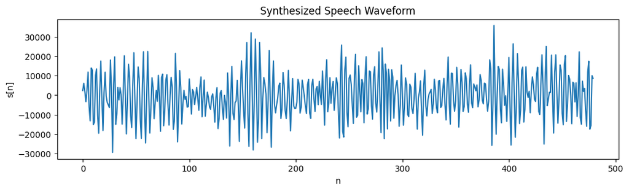

[interactive chart not shown]

```python
# generating /s/ with a white noise excitation
def filter_with_noise_excitation(E, a, len):
    y = np.zeros(a.shape[0]+len-1)
    y[a.shape[0]-1] = np.sqrt(E) * np.random.rand()
    for i in range(a.shape[0], a.shape[0]+len-1):
        y[i] = np.dot(y[i-a.shape[0]:i], a[::-1]) + np.sqrt(E) * np.random.randn()
    return y[a.shape[0]-1:]
synth_speech = filter_with_noise_excitation(E_, ak, synth_length)
synth_speech = deemphasis(synth_speech, alpha)
plt.figure(figsize=(12, 3))
plt.plot(synth_speech[:window_length])
plt.title("Synthesized Speech Waveform")
plt.xlabel("n")
plt.ylabel("s[n]")
plt.show()
Audio(data=synth_speech, rate=samp_rate)
```

Now this sounds much more like the /s/ utterance.